# Supplementary material

# Set up

```r
knitr::opts_chunk$set(echo = TRUE, error = TRUE)
require(knitr)
require(lubridate)
require(plyr)
require(dplyr)
require(boot)
require(pander)
require(reshape2)
require(ggplot2)
require(zoo)
require(stringr)
require(tidyr)
require(ggrepel)
require(mgcv)
require(cowplot)
require(egg)
require(patchwork)
require(ggrepel)
require(marmap)
require(sf)
require(tmaptools)
require(rnaturalearth)
require(rnaturalearthdata)
require(rnaturalearthhires)
require(rgdal)
require(RStoolbox)
require(pals)
require(ggnewscale)
require(ggspatial)

knitr::write_bib(c(.packages(), "knitr"), "packages.bib")
options(scipen=999)
```

Set directories

```r
direct <- "C:/Users/keyserf/Documents/Version_control_pandemic/Bycatch/"
direct_fns <- "C:/Users/keyserf/Documents/Github/FK/"
```

# Data preparation

Read in the trip data, 2004-2018

```r
bycatch_hist <- read.csv(paste0(direct, "data/Bycatch report historical.csv"), stringsAsFactors = F)
```

Prepare the trip-level discard data

```r
# max year
year <- 2018
# max month (all year, so 12)
maxmonth <- 12

# clean up the names in the data
bycatch_hist <- bycatch_hist[,!names(bycatch_hist) %in% names(bycatch_hist)[which(grepl(names(bycatch_hist), pattern = "X"))]]

names(bycatch_hist) <- c("Vessel", "CFV", "TRIP", "Trip.ID", "BOARD_DATE", "date.land", "OBSERVED_HOOKS", "TOTAL_HOOKS", "Proportion.dredges", "YT_TOTAL_SAMPLE_WT", "YT_PRORATED_WT", "COD_TOTAL_SAMPLE_WT", "COD_PRORATED_WT", "HAD_TOTAL_SAMPLE_WT", "HAD_PRORATED_WT", "hm.trip", "Split.trip")

# just for simplicity (borrowed other code)
discards_report <- bycatch_hist

# You might need to ymd these instead of dmy if you are getting a warning here...
discards_report$BOARD_DATE <- dmy(discards_report$BOARD_DATE)
#discards_report$BOARD_DATE <- ymd(discards_report$BOARD_DATE)
discards_report$date.land <- dmy(discards_report$date.land)
#discards_report$date.land <- ymd(discards_report$date.land)

# assign trips to month based on the month with the most days fished.
discards_report$startmonth <- month(discards_report$BOARD_DATE)
discards_report$endmonth <- month(discards_report$date.land)
discards_report$ndays_1 <- ifelse((discards_report$startmonth==discards_report$endmonth)==F,
                                  difftime((floor_date((discards_report$date.land),
                                                       unit="month")-days(1)),
                                           discards_report$BOARD_DATE, units="day"), NA)
discards_report$ndays_2 <- ifelse((discards_report$startmonth==discards_report$endmonth)==F,
                                  day(discards_report$date.land), NA)
discards_report$month <- as.numeric(ifelse((
  discards_report$startmonth == discards_report$endmonth) == T,
  month(discards_report$date.land),
  ifelse(discards_report$ndays_1 > discards_report$ndays_2,
         month(discards_report$BOARD_DATE),
         month(discards_report$date.land))))
discards_report$year <- year(discards_report$date.land)
discards_report <- arrange(dplyr::select(
  discards_report, -startmonth, -endmonth, -ndays_1, -ndays_2),
  year, month, date.land)

discards_report <- discards_report %>% arrange(year, month, date.land)

trip_summary <- discards_report %>%
  filter(year>2004) %>%
  group_by(year) %>%
  tally() %>%
  summarise(mean = mean(n))

tripsyear <- length(discards_report$Trip.ID[is.na(discards_report$Trip.ID)])
tripsold <- max(as.numeric(gsub(x= discards_report$Trip.ID[!is.na(discards_report$Trip.ID)], pattern=paste0("T", min(discards_report$year), "-"), replacement="")))

if(!discards_report$year[!is.na(discards_report$Trip.ID)][length(discards_report$Trip.ID[!is.na(discards_report$Trip.ID)])] ==
   year) tripsold <- 0

discards_report$Trip.ID[is.na(discards_report$Trip.ID)] <-
  c(paste0("T",unique(discards_report[is.na(discards_report$Trip.ID),]$year),
           "-", (tripsold + 1:tripsyear)))

discards_month <- ddply(.data=discards_report, .(year, month),
                        summarise,
                        PD_YTF = sum(YT_PRORATED_WT),
                        PD_COD = sum(COD_PRORATED_WT),
                        PD_HAD = sum(HAD_PRORATED_WT),
                        effort = sum(hm.trip))

allmonths <- arrange(expand.grid(year=unique(discards_month$year), month=1:12), year, month)

discards_month <- arrange(join(discards_month, allmonths, type="full"), year, month)

discards_month[discards_month$year==year & discards_month$month > maxmonth, c("PD_YTF", "PD_COD", "PD_HAD", "effort")] <- "NA"
```

Prepare the fishery data

```r
# source("C:/Documents/Offshore scallop/Assessment/Assessment_fns/Fishery/logs_and_fishery_data.r")
# logs_and_fish(loc="offshore",year = 2004:2018, direct="Y:/Offshore scallop/Assessment/")
# new.log.dat$year <- year(new.log.dat$fished)
# new.log.dat$month <- month(new.log.dat$fished)
# new.log.dat$date <- ymd(new.log.dat$date)
# old.log.dat$date <- ymd(old.log.dat$date)
#
# log.dat <- rbind(old.log.dat[, c("year", "month", "bank", "hm", "pro.repwt")], new.log.dat[, c("year", "month", "bank", "hm", "pro.repwt")])
# spat.dat <- rbind(old.log.dat[,c("year", "month", "date", "bank", "hm", "pro.repwt","lat", "lon", "numtow")], new.log.dat[,c("year", "month", "date", "bank", "hm", "pro.repwt","lat", "lon", "numtow")])
# save(log.dat, file=paste0(direct, "Reallocation/Data/log_dat.Rdata"))
# save(spat.dat, file=paste0(direct, "Reallocation/Data/spat_dat.Rdata"))
load(file=paste0(direct, "Reallocation/Data/log_dat.Rdata"))
load(file=paste0(direct, "Reallocation/Data/spat_dat.Rdata"))

months <- data.frame(month=format(ISOdate(2004,1:12,1),"%B"),num = 1:12)
fixmonth <- join(log.dat[log.dat$year <2009,], months, type="left")
log.dat[log.dat$year <2009,]$month <- fixmonth$num

log.dat$month <- as.numeric(as.character(log.dat$month))


fixmonth <- join(spat.dat[spat.dat$year <2009,], months, type="left")
spat.dat[spat.dat$year <2009,]$month <- fixmonth$num

spat.dat$month <- as.numeric(as.character(spat.dat$month))

cumsum_narm <- function(x) {
  x[is.na(x)] <- 0
  return(cumsum(x))
}

fleeteffort <- ddply(.data=log.dat[log.dat$bank %in% c("GBa", "GBb"),],
                     .(year, month),
                     summarize,
                     totaleffort = sum(hm, na.rm=T))

fleetlandings <- ddply(.data=log.dat[log.dat$bank %in% c("GBa", "GBb"),],
                     .(year, month),
                     summarize,
                     totalcatch = sum(pro.repwt, na.rm=T))

fleetmonths <- expand.grid(year=min(fleetlandings$year):max(fleetlandings$year),
                           month=unique(fleetlandings$month))

fleeteffort <- join(fleeteffort, fleetmonths, type="full")
fleeteffort$totaleffort[is.na(fleeteffort$totaleffort)] <- 0

fleetlandings <- join(fleetlandings, fleetmonths, type="full")
fleetlandings$totalcatch[is.na(fleetlandings$totalcatch)] <- 0

## calculate cumulative landings in fleetlandings first
fleetlandings_cumu <- fleetlandings %>%
  group_by(year) %>%
  mutate_at(vars(totalcatch), cumsum_narm)

names(fleetlandings_cumu) <- c("year", "month", "cumulativecatch")

fleetlandings_eoy <- ddply(.data=fleetlandings_cumu, .(year),
                           summarize,
                           finalcatch = max(cumulativecatch))

fleetlandings_cumu <- join(data.frame(fleetlandings_cumu), fleetlandings_eoy, type="left")

## cumulative effort
fleeteffort_cumu <- fleeteffort %>%
  group_by(year) %>%
  mutate_at(vars(totaleffort), cumsum_narm)

names(fleeteffort_cumu) <- c("year", "month", "cumulativeeffort")

fleeteffort_eoy <- ddply(.data=fleeteffort_cumu, .(year),
                           summarize,
                           finaleffort = max(cumulativeeffort))

fleeteffort_cumu <- join(data.frame(fleeteffort_cumu), fleeteffort_eoy, type="left")

## need the TACs too
TAC <- read.csv(paste0(direct, "data/Ref_pts_and_tac.csv"))
TAC <- TAC[TAC$bank %in% c("GBa", "GBb") & TAC$year >2003 & TAC$year < 2019,]
# Tonnes to KG
TAC$TAC <- TAC$TAC * 1000
TACs <- ddply(.data=TAC[,c("year", "TAC", "bank")], .(year),
              summarize,
              TAC=sum(TAC))
```

Join fishery with discards data

```r
#join the landings data
discards_month <- join(discards_month, fleetlandings_cumu, type="full")

# join the effort data
discards_month <- join(discards_month, fleeteffort_cumu, type="full")
discards_month <- join(discards_month, fleeteffort[!(fleeteffort$year == year & fleeteffort$month > maxmonth),], type="left")

#join the TAC data
discards_month <- join(discards_month, TACs, type="left")

discards_month <- discards_month %>% arrange(year, month)

discards_month <- data.frame(apply(discards_month, 2, function(x) as.numeric(x)))
```

Start calculating derived discard metrics

```r
## discard rate (DR) - NOT MOVING AVERAGE
DR <- NULL
discards_month_melt <- melt(discards_month, measure.vars = c("PD_YTF", "PD_COD", "PD_HAD"))
discards_month_melt$DR <- discards_month_melt$value / discards_month_melt$effort

discards_month_melt$DRsp <- gsub(x=discards_month_melt$variable, pattern="PD_", "DR_")
names(discards_month_melt) <- c("year", "month", "effort", "cumulativecatch", "finalcatch", "cumulaltiveeffort", "finaleffort", "totaleffort", "TAC", "name", "PD", "DR", "DRsp")

## widen melted df to fill in missing DRs
discards_month_melt_1 <- dcast(discards_month_melt, year + month + effort + totaleffort ~ name, value.var = "PD")
discards_month_melt_2 <- dcast(discards_month_melt, year + month + effort + totaleffort ~ DRsp, value.var = "DR")
discards_month_2 <- join(discards_month_melt_1, discards_month_melt_2, type="full")
discards_month <- join(discards_month_2, select(discards_month, -PD_YTF, -PD_HAD, -PD_COD))

species <- c("COD", "HAD", "YTF")
#### input missing DRs
# list of missing months
missmonths <- discards_month[is.na(discards_month$DR_COD) & !is.na(discards_month$totaleffort), c("year", "month")]

# number of missing months?
missmonths2 <- discards_month[is.na(discards_month$DR_COD) & !is.na(discards_month$totaleffort) & discards_month$totaleffort>0 &
                              discards_month$year>2004, c("year", "month")]
# for text on missing months
dim(missmonths2)
dim(discards_month[discards_month$year>2004 &  discards_month$totaleffort>0,])

for(i in 2:dim(discards_month)[1]) {
  for(j in 1:length(species)){
    if(is.na(discards_month[i ,paste0("DR_", species[j])])) {
      discards_month[i,paste0("DR_", species[j])] <- discards_month[i-1,paste0("DR_", species[j])]
    }
  }
}

## Discard estimate (mt)
discards_month$D_YTF <- discards_month$DR_YTF*discards_month$totaleffort*0.001
discards_month$D_COD <- discards_month$DR_COD*discards_month$totaleffort*0.001
discards_month$D_HAD <- discards_month$DR_HAD*discards_month$totaleffort*0.001

## cumulative annual discard (mt)
DR_D_CAD <- discards_month %>%
  group_by(year) %>%
  mutate_at(vars(D_YTF, D_COD, D_HAD), cumsum_narm)

names(DR_D_CAD)[which(names(DR_D_CAD)%in% c("D_YTF", "D_COD", "D_HAD"))] <- c("CD_YTF", "CD_COD", "CD_HAD")

discards_month <- join(discards_month, DR_D_CAD, type="full")
```

Apply the landings method

```r
# This method normally uses a 10% error metric in case of overruns, so this is what they would estimate mid-year for the end of year totals. But we're not going to use the 10% estimate!
discards_month$RM_COD <- discards_month$CD_COD * (discards_month$TAC / discards_month$cumulativecatch)# * 1.1
discards_month$RM_HAD <- discards_month$CD_HAD * (discards_month$TAC / discards_month$cumulativecatch)# * 1.1
discards_month$RM_YTF <- discards_month$CD_YTF * (discards_month$TAC / discards_month$cumulativecatch)# * 1.1
```

Final data cleaning steps

```r
discards_month_melt_final <- melt(discards_month, id.vars=c("year", "month", "effort", "totaleffort", "cumulativeeffort", "finaleffort", "cumulativecatch", "finalcatch", "TAC"))
discards_month_melt_final$species <- str_sub(discards_month_melt_final$variable, -3)
discards_month_melt_final$species <- as.factor(discards_month_melt_final$species)
discards_month_melt_final$species <- factor(discards_month_melt_final$species, labels=c("Cod", "Haddock", "Yellowtail"))
discards_month_melt_final$variable <- gsub(x=str_sub(discards_month_melt_final$variable, 1, -4), "_", "")
discards_month_melt_final$date <- ymd(paste0(discards_month_melt_final$year, "-", discards_month_melt_final$month, "-", 15))

# note the ones where DR assumed
missmonths$missing <- "missing"

discards_month_melt_final <- join(discards_month_melt_final, missmonths, type="full")

discards_month_melt_final$value[discards_month_melt_final$year==2004 & discards_month_melt_final$variable=="RM" & discards_month_melt_final$value=="0"] <- NA

# cumulative relative discards
discards_month_melt_final_eoy <- discards_month_melt_final[discards_month_melt_final$variable=="CD" & discards_month_melt_final$month==12,c("year", "species", "value")]
names(discards_month_melt_final_eoy) <- c("year", "species", "eoy_total")

discards_month_melt_final <- join(discards_month_melt_final, discards_month_melt_final_eoy, type="full")
```

# Analysis

Developing the seasonal models

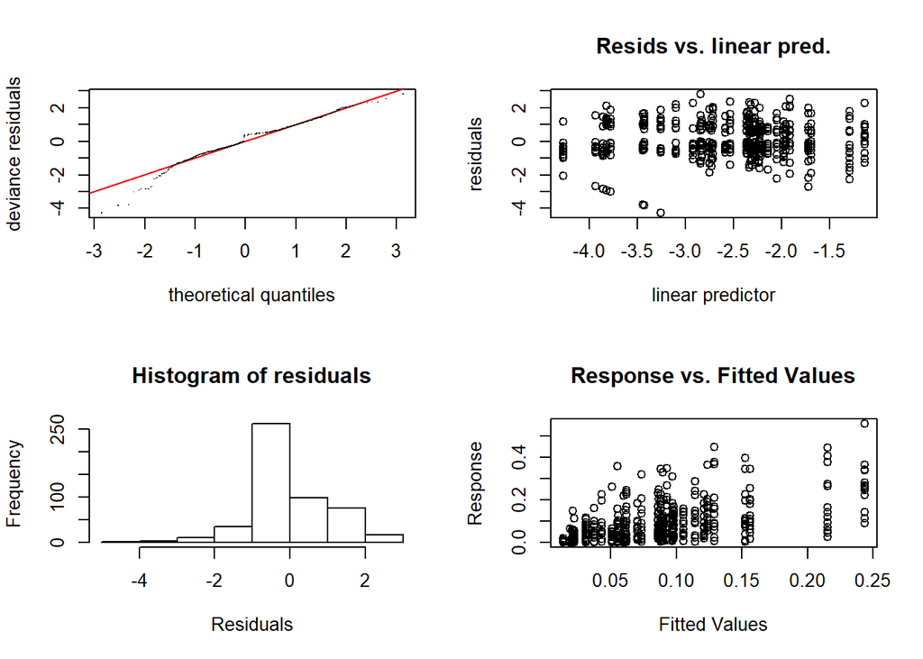

```r
# Plot the raw data and toss a gam smooth through it and see how it looks
discards_month_melt_final$meanrelative <- discards_month_melt_final$value/discards_month_melt_final$eoy_total

# ggplot(data = discards_month_melt_final[discards_month_melt$year > 2004 & discards_month_melt_final$variable == "D",], aes(month,meanrelative,colour = year)) + facet_wrap(~species) +
#   geom_point() + geom_smooth(method="gam")
# # Dang 0's break the easy peasy methods...

# # But better still let's make a proper Gam
# # The gam will be a beta family, alternatively we could use an offset with something like a gamma (but 0's), so this is just easier, if it works
gam.dat <- discards_month_melt_final[discards_month_melt_final$variable == "D",]
gam.dat <- gam.dat[gam.dat$year > 2004,]
gam.mod <- gam(meanrelative ~ s(month,by=species),family = betar(),data= gam.dat)
#plot(gam.mod)
gam.check(gam.mod)
```

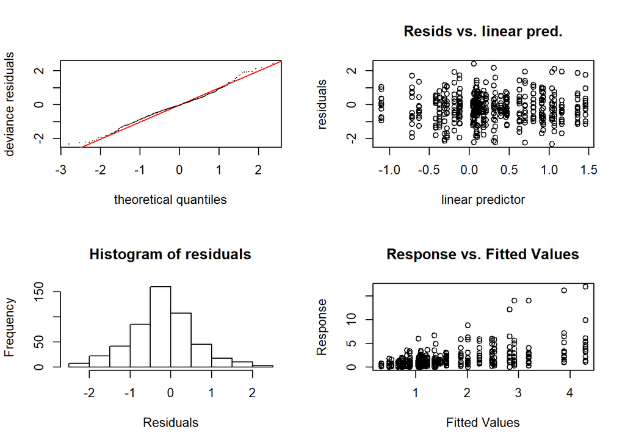

```r
new.dat <- expand.grid(species = c("Cod", "Haddock","Yellowtail"),month = seq(1,12,by=0.1))
new.dat$pred <- predict(gam.mod,newdata= new.dat,type="response")
new.dat$pred.logit <- predict(gam.mod,newdata= new.dat)
new.dat$se <- predict(gam.mod,newdata= new.dat,se.fit=T)$se.fit
new.dat$LCI <- inv.logit(new.dat$pred.logit - 2*new.dat$se)
new.dat$UCI <- inv.logit(new.dat$pred.logit + 2*new.dat$se)

# Discard rate anomaly too
# We could also make a discard rate anomoly plot, if we standardize against the median discard rate in a given year this same thing would
# indicate how much a given month lands above average.

# So this is the piping version
gam.dat2 <- discards_month_melt_final[discards_month_melt_final$variable == "DR",]
gam.dat2 <- gam.dat2[gam.dat2$year > 2004,]
tmp <- gam.dat2 %>% # SO send gam.dat into this grouping
          group_by(year,species) %>% # Then run the calculation on this group
          dplyr::summarize(median.DR = median(value,na.rm=T)) # And here's your median
# Now stitch these together with a join
gam.dat2 <- left_join(gam.dat2,tmp,by = c("year","species"))
gam.dat2$DR.anomaly <- gam.dat2$value/gam.dat2$median.DR # Note I've divided here not subtracted, so we are looking at a proportional anomaly...

# Now for an anomaly model.. Note the anomalies are in terms of a proportion which is kinda weird, but what
# this represents is the propotional deviation from the annual median discard rate.  A value of 1 means
# it was an average month in a given year

gam.dr.a.mod <- gam(DR.anomaly ~ month + s(month,by=species),family = Gamma(link="log"),data= gam.dat2[gam.dat2$DR.anomaly>0,])

gam.check(gam.dr.a.mod)
```

```r
new.dat$pred.anom <- predict(gam.dr.a.mod,newdata= new.dat,type="response")
new.dat$pred.anom.link <- predict(gam.dr.a.mod,newdata= new.dat, type="link")
new.dat$anom.se <- predict(gam.dr.a.mod,newdata= new.dat,se.fit=T)$se.fit
new.dat$anom.LCI <- exp(new.dat$pred.anom.link - 2*new.dat$anom.se)
new.dat$anom.UCI <- exp(new.dat$pred.anom.link + 2*new.dat$anom.se)

# values for text

#The proportional discards increased rapidly from X in January to Y in April.
new.dat$pred[new.dat$species=="Cod" & new.dat$month==1]
new.dat$pred[new.dat$species=="Cod" & new.dat$month==4]

new.dat$pred[new.dat$species=="Haddock" & new.dat$month==1]
new.dat$pred[new.dat$species=="Haddock" & new.dat$month==4]

new.dat$pred[new.dat$species=="Yellowtail" & new.dat$month==1]
new.dat$pred[new.dat$species=="Yellowtail" & new.dat$month==5]
```

Projection model for discards

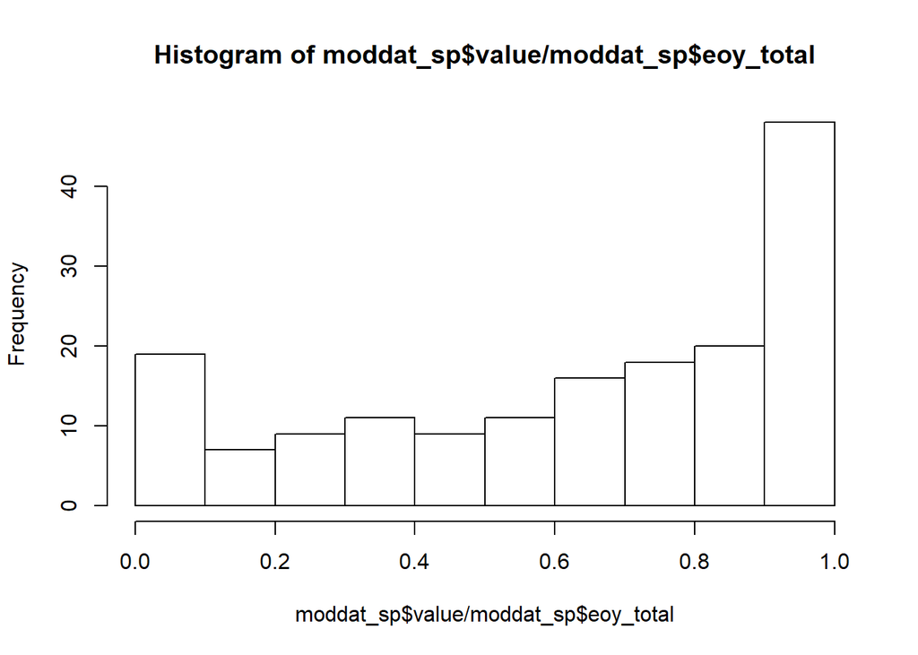

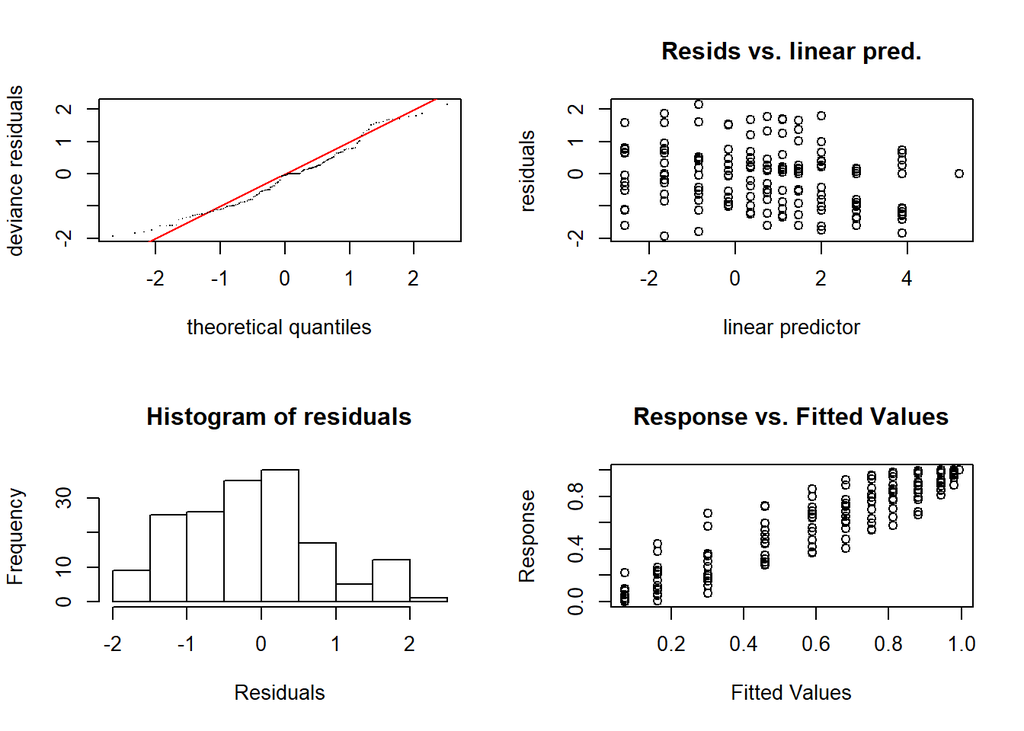

```r
discards_month_melt_final$propcatch <- discards_month_melt_final$cumulativecatch/discards_month_melt_final$finalcatch
moddat <- discards_month_melt_final[discards_month_melt_final$year > 2004 & discards_month_melt_final$variable=="CD", c("year", "month", "species", "value", "eoy_total")]

moddat$value[is.na(moddat$value)] <- 0

moddat$prop <- moddat$value/moddat$eoy_total

moddat$record <- 1:nrow(moddat)

discard_gam <- function(speciesID){
  moddat_sp <- moddat[moddat$species==speciesID,]

  print(hist(moddat_sp$value/moddat_sp$eoy_total))

  require(mgcv)

  mod_s <- gam(data = moddat_sp,
                  formula = value/eoy_total ~ s(month),
                  family=betar(link="logit"))

  checkplots <- gam.check(mod_s)

  summary(mod_s)

   fits <- cbind(as.data.frame(predict(mod_s, se.fit=T, unconditional=T, type="link")), # unconditional=T based on advice from predict.gam/plot.gam (sewithMean option)
                          mod_s$model)
  require(boot)

  if(mod_s$family$link == "logit") ilink <- function(x) inv.logit(x)
  if(mod_s$family$link == "log") ilink <- function(x) exp(x)

  modplot <- ggplot() +
    geom_ribbon(data=fits, aes(month, ymin=ilink(fit-1.96*se.fit), ymax=ilink(fit+1.96*se.fit)), fill="grey", alpha=0.5) +
    geom_point(data=fits, aes(month, `value/eoy_total`), size=1) +
    geom_line(data=fits, aes(month, ilink(fit)), colour="black") +
    geom_line(data=fits, aes(month, ilink(fit-1.96*se.fit)), lty="dashed", colour="black")+
    geom_line(data=fits, aes(month, ilink(fit+1.96*se.fit)), lty="dashed", colour="black") +
    theme_bw() +
    theme(panel.grid=element_blank()) +
    #ggtitle(paste0(speciesID, " - ", c(mod_s$call))) +
    geom_text(aes(1,1), label=speciesID, size=4, vjust=1, hjust=0) +
    ylab(expression(paste("Cumulative proportional discards")))+#, frac(CD[paste("m,y")],D[y])))) +
    xlab("Month (m)") +
    scale_x_continuous(breaks=1:12, labels=1:12, expand=c(0.02,0.02))+
    scale_y_continuous(expand=c(0.02,0.02))

  se_month <- ddply(.data=fits, .(month),
        summarize,
        se.fit.invlogit.lo = inv.logit(unique(fit - 1.96* se.fit)),
        se.fit.invlogit.up = inv.logit(unique(fit + 1.96* se.fit)),
        fit.invlogit = inv.logit(unique(fit)))

  return(list(moddat_sp=moddat_sp, mod_s=mod_s, checkplots=checkplots, fits=fits, se_month=se_month, modplot=modplot))
}

codmod <- discard_gam(speciesID="Cod")
```

```r
hadmod <- discard_gam(speciesID="Haddock")
```

[figure not shown]

[figure not shown]

```r
ytfmod <- discard_gam(speciesID="Yellowtail")
```

[figure not shown]

[figure not shown]

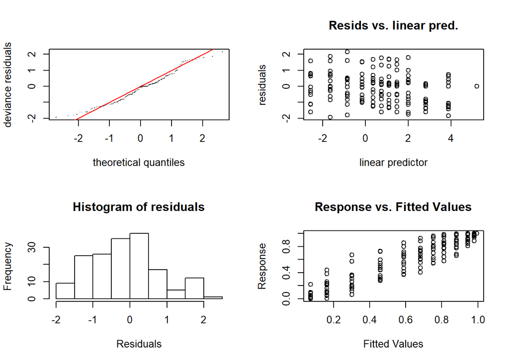

```r
summary(codmod$mod_s)
summary(hadmod$mod_s)
summary(ytfmod$mod_s)

gam.check(codmod$mod_s)
```

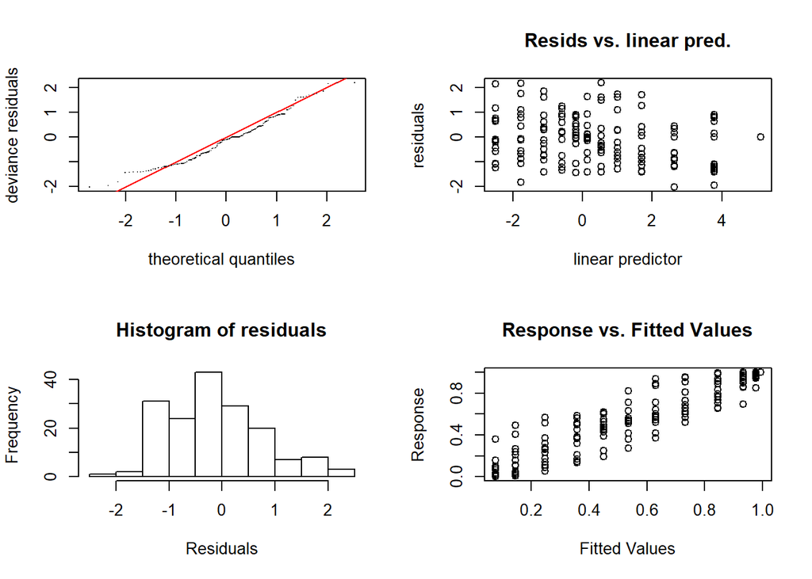

```r
gam.check(hadmod$mod_s)
```

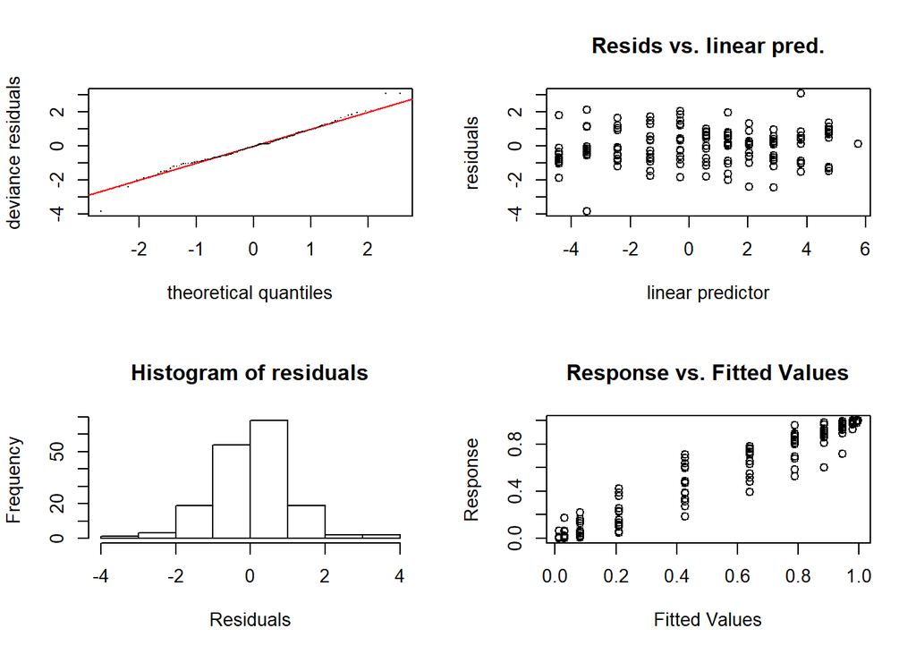

```r
gam.check(ytfmod$mod_s)
```

Compare the projections from the landings method and seasonal method using Relative Error metric for bias and precision.

1. Get the relative error from the landings method

```r
compare_rm <- dcast(data = discards_month_melt_final[discards_month_melt_final$variable %in% c("RM"),], year + month + species~ variable)

compare_rm <- join(compare_rm[compare_rm$year > 2004,],
                   discards_month_melt_final[discards_month_melt_final$variable =="CD" &
                                               discards_month_melt_final$month==12 &
                                               discards_month_melt_final$year>2004, c("year", "species", "value")])

compare_rm$rel.error <- compare_rm$RM/compare_rm$value# - 1
```

2. Do the proration for the seasonal model and calculate the relative error all at once

```r
prorate_eoy_gam <- function(mod, speciesID){

  # join data with model fitted means and CIs
  prorate_df <-join(mod$moddat_sp, mod$se_month, type="left")

  # prorate the estimates by the model fits
  prorate_df2 <- data.frame(eoy_est = prorate_df$value / prorate_df$fit.invlogit, month=prorate_df$month, year=prorate_df$year,  eoy_total = prorate_df$eoy_total, type="Fitted mean")

  # calculate the estimation errors (proportional and absolute)
  prorate_df2$rel.error <- prorate_df2$eoy_est/prorate_df2$eoy_total# - 1

  return(list(prorated_est = prorate_df2))#, proportional=proportional, magnitude=magnitude, table_GAM=table_GAM))
}

GAM_res_cod <- prorate_eoy_gam(speciesID="Cod", mod=codmod)
GAM_res_had <- prorate_eoy_gam(speciesID="Haddock", mod=hadmod)
GAM_res_ytf <- prorate_eoy_gam(speciesID="Yellowtail", mod=ytfmod)
```

3. Clean up the relative error data

```r
tac_estimates <- compare_rm[compare_rm$year > 2004,]
gam_estimates <- rbind(data.frame(GAM_res_cod$prorated_est, species="Cod"),
                       data.frame(GAM_res_had$prorated_est, species="Haddock"),
                       data.frame(GAM_res_ytf$prorated_est, species="Yellowtail"))

# match up the names
names(tac_estimates)[which(names(tac_estimates)=="RM")] <- "est"
names(tac_estimates)[which(names(tac_estimates)=="value")] <- "real"

names(gam_estimates)[which(names(gam_estimates)=="eoy_est")] <- "est"
names(gam_estimates)[which(names(gam_estimates)=="eoy_total")] <- "real"
```

4. Model it. GLS model gives shrinking CIs over time, which make the most sense! We did try glm & gam (with gamma, beta, and gaussian distributions too). Based on https://rpubs.com/bbolker/6298

$$\begin{split} Y_{ij} & = \delta_i + \epsilon_{ij} \\ \epsilon_{ij} & \sim \text{Normal}(0,\sigma^2_i) ; \end{split}$$

```r
all_estimates <- rbind(data.frame(tac_estimates[, c("year", "month", "species", "est", "real", "rel.error")], type="tac"),
                       data.frame(gam_estimates[, c("year", "month", "species", "est", "real", "rel.error")], type="gam"))

# a function that will compare the estimation error between methods. uses the un-summarized est/real values as the response, and month and type as a predictor.
est_mod <- function(speciesID, model, family){

  temp_dat <- all_estimates

  # if(model=="glm" & family=="gamma"){
  #   # for the Gamma model, need to adjust 0's to slightly above 0. Dave suggested half of the minimum value that isn't 0. Check them out first though... it's only 2 months. It happened because the model estimated 0, but the real value was 3.4.
  #    mod <- glm(data=temp_dat[temp_dat$species==speciesID &
  #                                   !temp_dat$type=="glm" & temp_dat$rel.error>0,], rel.error ~ as.factor(type)*as.factor(month), family=Gamma(link="log"))
  # }

  # if(model=="gam" & family=="normal"){
  #   mod <- gam(data=all_estimates[all_estimates$species==speciesID & !all_estimates$type=="glm",],
  #              rel.error ~ as.factor(type) + s(month, by=as.factor(type)))
  # }

  # if(model=="gam" & family=="gamma"){
  #
  # mod <- gam(data=temp_dat[temp_dat$species==speciesID & !temp_dat$type=="glm" & temp_dat$rel.error>0,],
  #            rel.error ~ s(month, by=as.factor(type)) + as.factor(type),
  #            family=Gamma(link="log"), method = "REML")
  # }

  if(model=="gls"){
    temp_dat$month <- as.factor(temp_dat$month)
    mod <- gls(data = temp_dat[temp_dat$species==speciesID & !temp_dat$type=="glm" & temp_dat$rel.error >0,],
               log(rel.error) ~ type*month -type -month - 1,
               weights = varIdent(form = ~1 | month))

    # mod <- gls(data = temp_dat[temp_dat$species==speciesID & !temp_dat$type=="glm" & temp_dat$rel.error >0,],
    #            log(rel.error) ~ type*month -type -month - 1,
    #            weights = varIdent(form = ~1))
    # AIC was higher than the one above.

    # mod3 <- gls(data = temp_dat[temp_dat$species==speciesID & !temp_dat$type=="glm" & temp_dat$rel.error >0,],
    #            log(rel.error) ~ type*month -type -month - 1,
    #            weights = varIdent(form = ~1 | month*type))
    #   Error in gls(data = temp_dat[temp_dat$species == speciesID & !temp_dat$type ==  :
    # false convergence (8)
  }

  # if(model=="gam"){
  #   source(paste0(direct_fns, "/Bycatch_fns/gam_post_simulate.R"))
  #   gam_post_sim_plot <- gam_post_simulate(gamobj=mod, x="month", y="rel.error")
  # }
  #
  est_mod_sum <- summary(mod)
  #est_mod_sum_coef <- as.data.frame(coef(est_mod_sum))

  # if(!model=="gls"){
  # est_mod_sum_coef <- cbind(
  #   as.data.frame(
  #     predict(object = mod,
  #             se.fit=T,
  #             unconditional=T,  #based on advice from predict.gam/plot.gam (sewithMean option)
  #             type="link",
  #             newdata = expand.grid(
  #               type=c("tac", "gam"),
  #               month=1:12))),
  #                         #mod$model)
  #   expand.grid(
  #               type=c("tac", "gam"),
  #               month=1:12))
  #
  # est_mod_sum_coef <- unique(est_mod_sum_coef)
  # }
  #
  if(model=="gls"){
    est_mod_sum_coef <- as.data.frame(coef(summary(mod)))
    est_mod_sum_coef$month <- rep(1:12, each=2)
    est_mod_sum_coef$type <- rep(c("tac", "gam"), 12)
    est_mod_sum_coef$AIC <- summary(mod)$AIC
    gam_post_sim_plot <- NULL
  }

  #est_mod_sum_coef$month <- str_extract(row.names(est_mod_sum_coef), "\\-*\\d+\\.*\\d*")
  #est_mod_sum_coef$type <- str_sub(row.names(est_mod_sum_coef), 5, 7)
  est_mod_sum_coef$species <- speciesID

  return(list(coef=est_mod_sum_coef, mod=mod, gam_post_sim_plot=gam_post_sim_plot))
}


##### RUN THE MODELS HERE:

est_mod_cod <- est_mod("Cod", model="gls", family="gamma")
est_mod_had <- est_mod("Haddock", model="gls", family="gamma")
est_mod_ytf <- est_mod("Yellowtail", model="gls", family="gamma")
est_mod_coef <- rbind(est_mod_cod$coef, est_mod_had$coef, est_mod_ytf$coef)


##### Tidy up the predict output for interpretation purposes

# if("gam" %in% as.character(est_mod_cod$mod$call)[1]){
# est_mod_sim <- rbind(data.frame(est_mod_cod$gam_post_sim_plot$pred, species="Cod"),
#                      data.frame(est_mod_had$gam_post_sim_plot$pred, species="Haddock"),
#                      data.frame(est_mod_ytf$gam_post_sim_plot$pred, species="Yellowtail"))
# est_mod_coef$model <- "gam"
# }

# if("residual.scale" %in% names(est_mod_coef)) {
#   est_mod_coef <- select(est_mod_coef, -residual.scale)
#   est_mod_coef$model <- "glm"
# }

if("gls" %in% as.character(est_mod_cod$mod$call)[1]){
  est_mod_coef <- select(est_mod_coef, Value, Std.Error, type, month, species)
  est_mod_coef$model <- "gls"
  }

names(est_mod_coef) <- c("Estimate", "se.fit", "type",
                         "month",  "species", "model")

# if(!"gls" %in% as.character(est_mod_cod$mod$call)[1]){
#   if(est_mod_cod$mod$family$link == "logit") ilink <- function(x) inv.logit(x)
#   if(est_mod_cod$mod$family$link == "log") ilink <- function(x) exp(x)
#   if(est_mod_cod$mod$family$link == "identity") ilink <- function(x) x
# }

# we manually log-transformed the data for the GLS so we have to force it back to the response scale
if("gls" %in% as.character(est_mod_cod$mod$call)[1]) ilink <- function(x) exp(x)

# est_mod_coef$range_lo <- ilink(est_mod_coef$Estimate - 1.96*est_mod_coef$se.fit)
# est_mod_coef$range_hi <- ilink(est_mod_coef$Estimate + 1.96*est_mod_coef$se.fit)

# if("gam" %in% as.character(est_mod_cod$mod$call)[1]){
# est_mod_sim <- unique(select(est_mod_sim, fit, uprP, lwrP, uprS, lwrS, month, as.factor.type., compare, species))
# }
```

Saving some outputs

```r
figure6_summary <- unique(data.frame(type=est_mod_coef$type, species=est_mod_coef$species, month=est_mod_coef$month, Estimate=est_mod_coef$Estimate, se.fit=est_mod_coef$se.fit))
figure6_summary$y <- ilink(figure6_summary$Estimate)
figure6_summary$y_lo <- ilink(figure6_summary$Estimate-1.96*figure6_summary$se.fit)
figure6_summary$y_up <- ilink(figure6_summary$Estimate+1.96*figure6_summary$se.fit)
figure6_summary$CIsize <- figure6_summary$y_up - figure6_summary$y_lo
figure6_summary_CI <- dcast(data=figure6_summary[, c("type", "species", "month", "CIsize", "y_lo", "y_up")], species + month ~ type, value.var = "CIsize")
names(figure6_summary_CI)[3:4] <- paste0(names(figure6_summary_CI)[3:4], "_CIsize")
figure6_summary_lo <- dcast(data=figure6_summary[, c("type", "species", "month", "se.fit", "y_lo", "y_up")], species + month ~ type, value.var = "y_lo")
names(figure6_summary_lo)[3:4] <- paste0(names(figure6_summary_lo)[3:4], "_lo")
figure6_summary_up <- dcast(data=figure6_summary[, c("type", "species", "month", "se.fit", "y_lo", "y_up")], species + month ~ type, value.var = "y_up")
names(figure6_summary_up)[3:4] <- paste0(names(figure6_summary_up)[3:4], "_up")
figure6_summary <- join(figure6_summary_CI, figure6_summary_lo, type="full")
figure6_summary <- join(figure6_summary, figure6_summary_up, type="full")
#save(figure6_summary, file = paste0(direct, "Reallocation/Figures/figure6_summary.Rdata"))

##model info for text
modinfo <- list(codmod=codmod$mod_s, hadmod=hadmod$mod_s, ytfmod=ytfmod$mod_s, est_mod_coef=est_mod_coef, tac_estimates=tac_estimates, gam_estimates=gam_estimates)
#save(modinfo, file=paste0(direct, "reallocation/Data/modinfo.Rdata"))
```

# Figures

Figure 1

```r
source(paste0(direct_fns, "Assessment_fns/Maps/pectinid_projector_sf.R"))
source(paste0(direct_fns, "Assessment_fns/Maps/github_spatial_import.R"))

extent2 <- data.frame(x=c(-72, -58), y=c(39.5, 48), crs=4326)
map_tmp <- pecjector(area = extent2, repo="github", add_layer=list(
  bathy=c(100, 'c', 1000),
  eez="eez",
  #nafo="main",
  #sfa="offshore",
  scale.bar = c("br", 0.3)),
  #direct = "C:/Users/keyserf/Documents/Version_control_pandemic/Offshore/Assessment/",
  direct_fns="C:/Users/keyserf/Documents/Github/Assessment_fns/",
  plot_package = "ggplot2", plot = F)

# import offshore data using the *new* github_spatial_import function!
# offshore <- github_spatial_import(subfolder = "offshore", zipname = "offshore.zip", direct_fns="C:/Users/keyserf/Documents/Github/Assessment_fns/")
# offshore <- offshore[offshore$ID %in% c("GBa", "GBb"),]
# SFA27 <- st_union(x = offshore)

# i wanted the bathymetry contours to be a bit lighter
map_tmp$layers[[2]]$aes_params$colour <- "blue"
map_tmp$layers[[2]]$aes_params$alpha <- 0.25

# set up the labels
labels <- data.frame(labs = c("Georges Bank", "Canada", "USA"), #"SFA 27"),
                     x = c(-67.75, -66,-69),# -66),
                     y = c(41.28, 43, 43))#, 41.25))

figure1 <- map_tmp +
  #geom_sf(data=SFA27, fill="lightgreen", alpha=0.25) + # highlight GB in green
  theme(panel.background=element_rect(fill="white"), panel.grid=element_blank(), panel.border=element_rect(fill=NA, size = 1)) +
  #annotate(geom="text", x=-65.5, y=44.2, label="Georges Bank", size=3) +
  geom_text_repel(data=labels[labels$labs=="SFA 27",], aes(x=x, y=y, label=labs), nudge_x=1.5, size=4) +
  geom_text(data=labels[!labels$labs %in% c("SFA 27", "Georges Bank"),], aes(x=x, y=y, label=labs), fontface="bold", size=6) +
  geom_text(data=labels[labels$labs == "Georges Bank",], aes(x=x, y=y, label=labs), angle=30, fontface="italic", colour="blue", size=4, alpha=0.5)
```

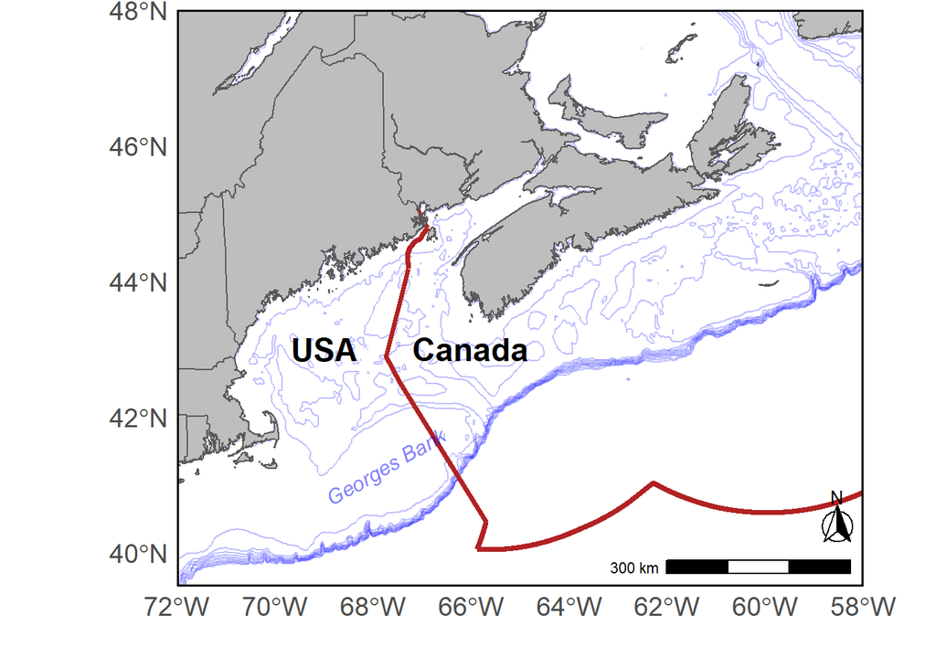

```r
#png(paste0("C:/Users/keyserf/Documents/Version_control_pandemic/Bycatch/reallocation/Figures/Map_GB_sf_nolines.png"), height=15, width=20, res=400, units="cm")
print(figure1)
```

```r
#dev.off()
```

Figure 2

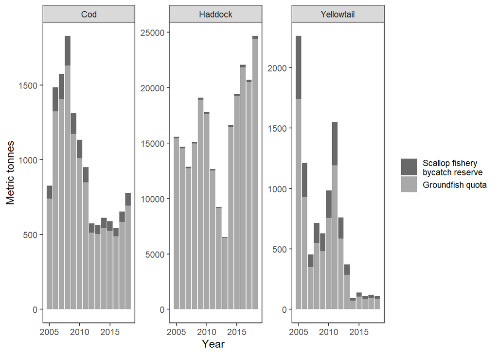

```r
quota <- read.csv(paste0(direct, "reallocation/Data/US and Canada TACs.csv"))

quota <- melt(quota, id.vars="X")
quota$species <- str_sub(quota$variable, start = 1, end=3)
quota$variable <- gsub(".*_","",quota$variable)

quota$value <- as.numeric(as.character(gsub(quota$value, pattern="*", replacement="", fixed=T)))

forplot <- quota[quota$variable %in% c("Canadian.quota", "Bycatch.reserve..12..", "Bycatch.reserve..1..", "Bycatch.reserve", "Bycatch.reserve.if.directed.fishery..30.."),]
forplot$Type[forplot$variable %in% c("Bycatch.reserve..12..", "Bycatch.reserve..1..", "Bycatch.reserve", "Bycatch.reserve.if.directed.fishery..30..")] <- str_sub(forplot$variable[forplot$variable %in% c("Bycatch.reserve..12..", "Bycatch.reserve..1..", "Bycatch.reserve", "Bycatch.reserve.if.directed.fishery..30..")], start = 1, end=15)

forplot[is.na(forplot$Type),]$Type <- forplot$variable[is.na(forplot$Type)]
forplot$Type <- gsub(x=forplot$Type, pattern=".", replacement=" ", fixed=T)

forplot$species[forplot$species == "COD"] <- "Cod"
forplot$species[forplot$species == "HAD"] <- "Haddock"
forplot$species[forplot$species == "YTF"] <- "Yellowtail"


labs <- data.frame(lab=c("12%", "1%", "30%\n(if directed fishery occurs)"),
           species=c("Cod", "Haddock", "Yellowtail"),
           y=c(max(forplot$value[forplot$Type=="Canadian quota" & forplot$species=="Cod"]),
               max(forplot$value[forplot$Type=="Canadian quota" & forplot$species=="Haddock"]),
               max(forplot$value[forplot$Type=="Canadian quota" & forplot$species=="Yellowtail"]))*1.15,
           x=c(min(forplot$X[forplot$Type=="Canadian quota" & forplot$species=="Cod"]),
               min(forplot$X[forplot$Type=="Canadian quota" & forplot$species=="Haddock"]),
               min(forplot$X[forplot$Type=="Canadian quota" & forplot$species=="Yellowtail"])))


fixquota <- dcast(forplot, X + species ~ variable)

# There was a directed fishery for YTF in Canada in 2011 and 2012, and prior to 2004.
fixquota$Bycatch.reserve.if.directed.fishery..30..[!fixquota$X %in% c(2011, 2012) & fixquota$species=="Yellowtail"] <- NA

fixquota$Bycatch.reserve[fixquota$X %in% c(2011, 2012) & fixquota$species=="Yellowtail"] <- NA

fixquota$BR_total <- rowSums(x = fixquota[, c("Bycatch.reserve..1..", "Bycatch.reserve..12..", "Bycatch.reserve.if.directed.fishery..30..")], na.rm=T)
fixquota$BR_total[fixquota$species=="Yellowtail" & !is.na(fixquota$Bycatch.reserve)] <- NA

fixquota$real.quota[!is.na(fixquota$BR_total)] <- fixquota$Canadian.quota[!is.na(fixquota$BR_total)] - fixquota$BR_total[!is.na(fixquota$BR_total)]
fixquota$real.quota[!is.na(fixquota$Bycatch.reserve)] <- fixquota$Canadian.quota[!is.na(fixquota$Bycatch.reserve)] - fixquota$Bycatch.reserve[!is.na(fixquota$Bycatch.reserve)]

fixquota <- melt(data=fixquota, id.vars = c("X", "species"))

fixquota$variable <- as.character(fixquota$variable)

fixquota$variable[fixquota$variable=="real.quota"] <- "Groundfish fleet"
fixquota$variable[fixquota$variable=="BR_total"] <- "Bycatch reserve (scallop)"
fixquota$variable[fixquota$variable=="Bycatch.reserve"] <- "Bycatch reserve (scallop and groundfish)"

# it would appear that the 2006 bycatch reserve was really just for scallop as there is also groundfish quota for that year
fixquota$value[fixquota$X==2006 & fixquota$species=="Yellowtail" & fixquota$variable=="Bycatch reserve (scallop)"] <- fixquota$value[fixquota$X==2006 & fixquota$species=="Yellowtail" & fixquota$variable=="Bycatch reserve (scallop and groundfish)"]

fixquota$value[fixquota$X==2006 & fixquota$species=="Yellowtail" & fixquota$variable=="Bycatch reserve (scallop and groundfish)"] <- NA

fixquota$reserve.calc <- NULL
fixquota$reserve.calc[fixquota$species=="Cod" & fixquota$variable=="Canadian.quota"] <-  fixquota$value[fixquota$species=="Cod" & fixquota$variable=="Canadian.quota"] * 0.12
fixquota$reserve.calc[fixquota$species=="Yellowtail" & fixquota$variable=="Canadian.quota"] <-  fixquota$value[fixquota$species=="Yellowtail" & fixquota$variable=="Canadian.quota"] * 0.30
fixquota$reserve.calc[fixquota$species=="Haddock" & fixquota$variable=="Canadian.quota"] <-  fixquota$value[fixquota$species=="Haddock" & fixquota$variable=="Canadian.quota"] * 0.01031

fixquota <- fixquota[!is.na(fixquota$reserve.calc),]
fixquota <- fixquota %>%
  rename(Canadian.quota = value) %>%
  dplyr::select(X, species, Canadian.quota, reserve.calc)

fixquota <- melt(data=fixquota, id.vars = c("X", "species"))

fixquota$variable <- factor(fixquota$variable, levels=c("reserve.calc", "Canadian.quota"))

figure2 <- ggplot() + geom_bar(data=fixquota[fixquota$variable %in% c("Canadian.quota", "reserve.calc") & fixquota$X > 2004,], aes(X, value, fill=variable), stat="identity") +
  #geom_text(data=labs, aes(x, y, label=paste0("Bycatch reserve: ", lab)), hjust=0, size=3, vjust=1)+
  facet_wrap(~species, scales="free") +
  theme_bw() + theme(panel.grid=element_blank()) +
  scale_x_continuous(breaks=seq(2005,2018,5))+
  scale_fill_manual(values=c("dimgrey", "darkgrey", "lightgrey"), name=NULL, labels=c("Scallop fishery\nbycatch reserve", "Groundfish quota"))+
  xlab("Year") +
  ylab("Metric tonnes")

#png(paste0(direct, "Reallocation/Figures/Quota_and_reserve.png"), height=3, width=7, units="in", res=420)
print(figure2)
```

```r
#dev.off()
```

Figure 3 TS of discards, calculated without moving average, and replacing missing months with previous month’s discard rate.

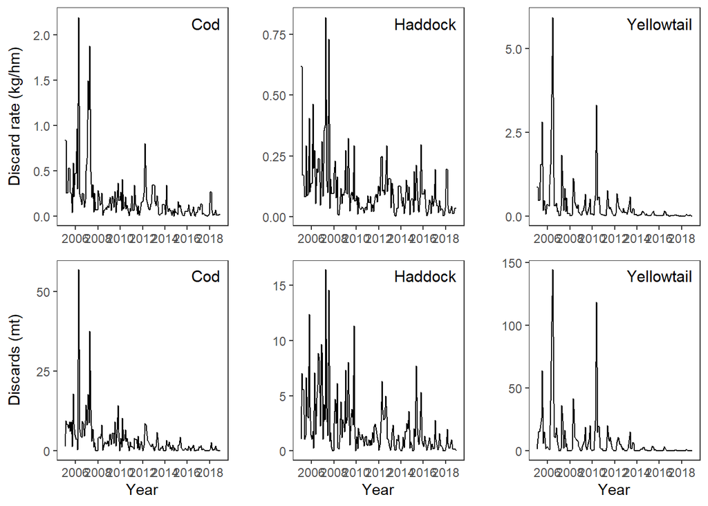

```r
### In months with no observer trips but with fishing, discards were calculated using previous month's DR
### In months with NO FISHING whatsoever, discards are 0.
plot_discards_ts <- function(speciesID){
  if(speciesID=="Cod") ybreaks <- c(0, 25, 50)
  if(speciesID=="Haddock") ybreaks <- c(0, 5, 10, 15, 20)
  if(speciesID=="Yellowtail") ybreaks <- c(0, 50, 100, 150)
  dt <- ggplot() + geom_line(data=discards_month_melt_final[discards_month_melt_final$variable=="D" & discards_month_melt_final$species==speciesID& discards_month_melt_final$year>2004,],
                     aes(date, value)) +
  # geom_point(data=discards_month_melt_final[!is.na(discards_month_melt_final$missing) & discards_month_melt_final$variable=="D",],
  #            aes(date, value + adj), shape="*", size=6, colour="blue")+
  scale_x_date(date_breaks="2 years", date_labels="%Y", limits = as.Date(c("2005-01-15","2018-12-15"))) +
  theme_bw() +
  theme(panel.grid=element_blank()) +
  ylab("Discards (mt)") +
  xlab("Year") +
  geom_text(aes(x=as.Date("2018-12-15"),y=max(discards_month_melt_final[discards_month_melt_final$variable=="D" & discards_month_melt_final$species==speciesID  & discards_month_melt_final$year>2004,]$value, na.rm=T)), label=speciesID, size=4, vjust=1, hjust=1) +
    scale_y_continuous(breaks = ybreaks)
  return(list(dt=dt))
}

plot_dt_cod <- plot_discards_ts(speciesID="Cod")
plot_dt_had <- plot_discards_ts(speciesID="Haddock")
plot_dt_ytf <- plot_discards_ts(speciesID="Yellowtail")

plot_discardrate_ts <- function(speciesID){
  if(speciesID=="Cod") ybreaks <- c(0, 0.5, 1, 1.5, 2)
  if(speciesID=="Haddock") ybreaks <- c(0, 0.25, 0.5, 0.75, 1)
  if(speciesID=="Yellowtail") ybreaks <- c(0, 2.5, 5, 7.5)
  drt <- ggplot() + geom_line(data=discards_month_melt_final[discards_month_melt_final$variable=="DR" & discards_month_melt_final$species==speciesID & discards_month_melt_final$year>2004,],
                     aes(date, value)) +
  #geom_point(data=discards_month_melt_final[!is.na(discards_month_melt_final$missing) & discards_month_melt_final$variable=="DR",],
  #          aes(date, value + adj), shape="*", size=6, colour="blue")+
  scale_x_date(date_breaks="2 years", date_labels="%Y", limits = as.Date(c("2005-01-15","2018-12-15"))) +
  theme_bw() +
  theme(panel.grid=element_blank()) +
  ylab("Discard rate (kg/hm)") +
  xlab("Year") +
  geom_text(aes(x=as.Date("2018-12-15"),y=max(discards_month_melt_final[discards_month_melt_final$variable=="DR" & discards_month_melt_final$species==speciesID & discards_month_melt_final$year>2004,]$value, na.rm=T)), label=speciesID, size=4, vjust=1, hjust=1) +
    scale_y_continuous(breaks = ybreaks)
  return(list(drt=drt))
}

plot_drt_cod <- plot_discardrate_ts(speciesID="Cod")
plot_drt_had <- plot_discardrate_ts(speciesID="Haddock")
plot_drt_ytf <- plot_discardrate_ts(speciesID="Yellowtail")

#png(paste0(direct, "reallocation/Figures/discards_timeseries_arrange.png"), type="cairo", width=24, height=10, units = "cm", res=400)
plot_grid(plot_drt_cod$drt + xlab(NULL), plot_drt_had$drt + ylab(NULL) + xlab(NULL), plot_drt_ytf$drt +ylab(NULL) + xlab(NULL), plot_dt_cod$dt, plot_dt_had$dt + ylab(NULL), plot_dt_ytf$dt + ylab(NULL), ncol=3, align="v")
```

```r
#dev.off()
```

Figure 4 (+ some figures for Dave’s paper)

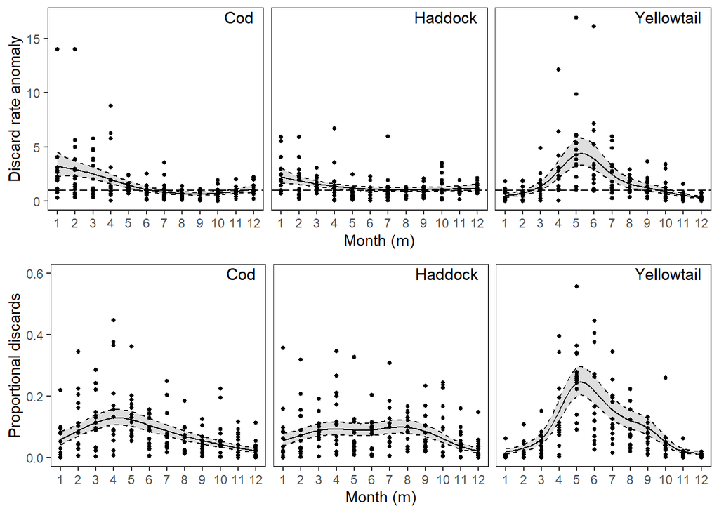

```r
figure4a <- ggplot(new.dat,aes(month,pred.anom)) +
  facet_wrap(~species) +
  geom_ribbon(aes(ymin = anom.LCI, ymax=anom.UCI), fill="grey", alpha=0.5 ) +
  geom_line(aes(month, anom.LCI), lty="dashed", colour="black")+
  geom_line( aes(month, anom.UCI), lty="dashed", colour="black") +
  geom_line() +
  geom_hline(yintercept=1, lty=5) +
  geom_point(data= gam.dat2, aes(month,DR.anomaly), size=1) +
  ylab("Discard rate anomaly") +  xlab("Month (m)") +
  scale_x_continuous(breaks=1:12)+
  theme_bw() + theme(panel.grid=element_blank(),legend.position = "none", strip.text = element_blank()) +
 geom_text(data=unique(gam.dat[gam.dat$month==12,c("month", "species")]), aes(12, 17, label=species), hjust=1, size=4)
#print(figure4a)

figure4b <- ggplot(new.dat,aes(month,pred)) +
  facet_wrap(~species) +
  geom_ribbon(aes(ymin = LCI, ymax=UCI), fill="grey", alpha=0.5 ) +
  geom_line(aes(month, LCI), lty="dashed", colour="black")+
  geom_line( aes(month, UCI), lty="dashed", colour="black") +
  geom_line() +
  geom_point(data= gam.dat, aes(month,meanrelative), size=1) +
  ylab("Proportional discards") +  xlab("Month (m)") +
  scale_x_continuous(breaks=1:12)+
  theme_bw() + theme(panel.grid=element_blank(),legend.position = "none", strip.text = element_blank()) +
  geom_text(data=unique(gam.dat[gam.dat$month==12,c("month", "species")]), aes(12, 0.6, label=species), hjust=1, size=4)
#print(figure4b)

#png(paste0(direct, "reallocation/Figures/Seasonal_discards_proportion_by_species_GAM_fit_FK_anomaly.png"), type="cairo", width=22, height=16, units = "cm", res=400)
grid.arrange(figure4a,
             figure4b,
             ncol=1)
```

```r
#dev.off()

# Same figure but with only Cod and Yellowtail for DK closure crap...
# dat_text <- data.frame(label = c("(a)", "(b)"),species = c("Cod","Yellowtail"),
#                        x = c(1,1),y = rep(max(gam.dat$meanrelative[gam.dat$species != "Haddock"],na.rm=T),2))
# p1.dk <- ggplot(new.dat[new.dat$species != "Haddock",],aes(month,pred)) + facet_wrap(~species) + geom_line(aes(colour=species),size=1.5,guides=F) +   geom_point(data= gam.dat[gam.dat$species != "Haddock",], aes(month,meanrelative,colour=species), alpha=0.5, size=1) +
#   geom_ribbon(aes(ymin = LCI, ymax=UCI,colour=species),alpha = 0.1) +
#   scale_x_continuous(breaks=1:12,labels = NULL)+ #c("Jan","Feb","Mar","Apr","May","Jun","Jul","Aug","Sep","Oct","Nov","Dec")) +
#   ylab("Monthly proportion of total discards") +  xlab("") +
#   theme_bw() + theme(panel.grid=element_blank(),legend.position = "none",text = element_text(size=18)) +
#   geom_text(dat_text, mapping = aes(x=x,y=y,label=label),size=6)
#ggsave(paste0(direct,"/reallocation/Figures/Seasonal_discards_proportion_by_species_YT_cod_only_GAM_fit.png"),width=16,height=8)

# Revision of the original figure with bigger text for presentation purposes
# ggplot() +
#   geom_point(data=seasonal, aes(month, meanrelative, colour=species, shape=species), size=2) +
#   geom_line(data=seasonal, aes(month, meanrelative, colour=species)) +
#   theme_bw() + xlab("")+
#   theme(panel.grid=element_blank(),text = element_text(size=24)) +
#   scale_x_continuous(limits = c(1,12), breaks=seq(1,12,1),labels = c("Jan","Feb","Mar","Apr","May","Jun","Jul","Aug","Sep","Oct","Nov","Dec")) +
#   ylab("Monthly proportion of total discards (mean)") +
#   scale_colour_brewer(name="Species", palette = 6, type="qual") +
#   scale_shape_discrete(name="Species")
#ggsave(paste0(direct,"/reallocation/Figures/seasonal discards_mean relative_presentation_version.png"),width=14,height=9)

#dev.off()
```

Figure 5

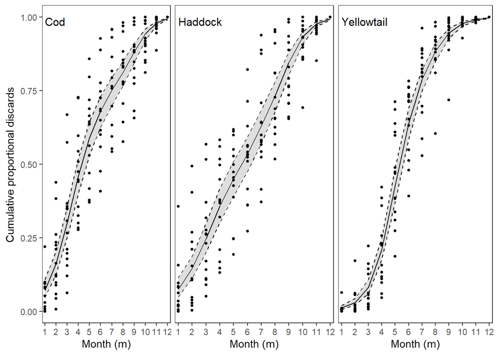

```r
#png(paste0(direct, "reallocation/Figures/GAMs.png"), type="cairo", width=22, height=10, units = "cm", res=400)
grid.arrange(codmod$modplot+ theme(plot.margin=unit(c(5.5, 1, 5.5, 5.5), "pt")),
             hadmod$modplot + ylab(NULL) + theme(plot.margin=unit(c(5.5, 1, 5.5, 1), "pt"), axis.ticks.y = element_blank(), axis.text.y=element_blank()),
             ytfmod$modplot + ylab(NULL) + theme(plot.margin=unit(c(5.5, 5.5, 5.5, 1), "pt"), axis.ticks.y = element_blank(), axis.text.y=element_blank()), ncol=3, widths=c(1.05, 1, 1))
```

```r
#dev.off()
```

Figure 6

```r
#png(paste0(direct, "Reallocation/Figures/Method_evaluation_results-GAM_gamma_REML.png"), height=10, width=22, units="cm", res=400)
figure6 <- ggplot() +
  geom_point(data=all_estimates[!all_estimates$type=="glm",], aes(as.numeric(month), rel.error, colour=as.character(type)), alpha=0.2, size=1, position = position_dodge(width=0.5))+#, show.legend = FALSE)+
  geom_ribbon(data=est_mod_coef, aes(as.numeric(month), ymin=ilink(Estimate-1.96*se.fit), ymax=ilink(Estimate+1.96*se.fit), fill=as.character(type)), alpha=0.3)+#, show.legend = FALSE) +
  geom_line(data=est_mod_coef, aes(as.numeric(month), ilink(Estimate), colour=as.character(type)), lwd=1)+#, show.legend = FALSE) +
   # geom_ribbon(data=est_mod_sim, aes(as.numeric(month), ymin=lwrS, ymax=uprS, group=as.factor.type., fill=as.factor.type.), alpha=0.3, show.legend = FALSE) +
   # geom_line(data=est_mod_sim, aes(as.numeric(month), ilink(fit), colour=as.factor.type., group=as.factor.type.), lwd=1, show.legend = FALSE) +
  theme_bw() + facet_wrap(~species) +
  theme(panel.grid=element_blank(), strip.text = element_blank()) +
  # geom_text(data=labs, aes(12, 6.25, label=species), hjust=1)+
  #geom_text(data=labs, aes(12, 5, label=species), hjust=1)+
  geom_hline(yintercept=1, linetype="dashed") +
  xlab("Month") +
  ylab("Relative error\n(estimate \u00B1 95% CI)") +
  scale_x_continuous(breaks=1:12)+
  scale_colour_brewer(name="Projection method", labels=c("Seasonal", "Landings"), direction = -1, palette = 6, type="qual") +
  scale_fill_brewer(name="Projection method", labels=c("Seasonal", "Landings"), direction = -1, palette = 6, type="qual") #+
  #ggtitle(unique(est_mod_coef$model))
# print(figure6)
#dev.off()
```

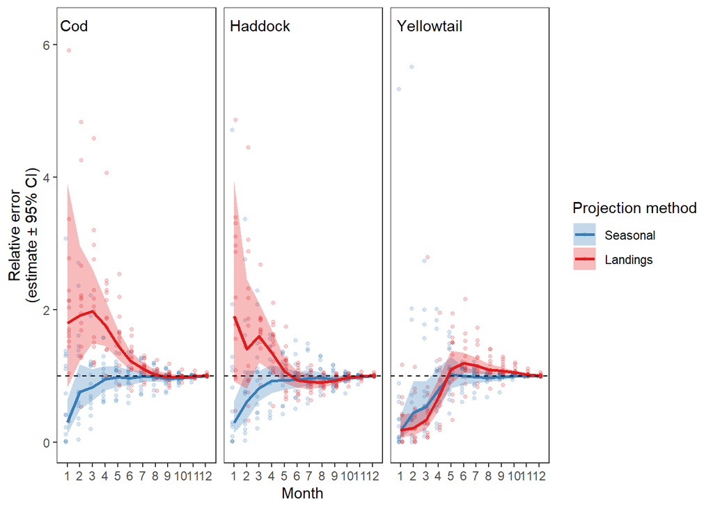

```r
figure6 <- tag_facet(figure6, tag_pool = c("Cod", "Haddock", "Yellowtail"), open = "", close="", hjust=-0.1, y=6.25, vjust=0.2, fontface = 1)
#png(paste0(direct, "Reallocation/Figures/Method_evaluation_results-GLS.png"), height=10, width=22, units="cm", res=400)
print(figure6)
```

```r
#dev.off()
```

# Package references

Auguie, Baptiste. 2017. *GridExtra: Miscellaneous Functions for "Grid" Graphics*. https://CRAN.R-project.org/package=gridExtra.

———. 2019. *Egg: Extensions for Ggplot2: Custom Geom, Custom Themes, Plot Alignment, Labelled Panels, Symmetric Scales, and Fixed Panel Size*. https://CRAN.R-project.org/package=egg.

Bivand, Roger, Tim Keitt, and Barry Rowlingson. 2020. *Rgdal: Bindings for the Geospatial Data Abstraction Library*. https://CRAN.R-project.org/package=rgdal.

Bivand, Roger S., Edzer Pebesma, and Virgilio Gomez-Rubio. 2013. *Applied Spatial Data Analysis with R, Second Edition*. Springer, NY. https://asdar-book.org/.

Campitelli, Elio. 2020. *Ggnewscale: Multiple Fill and Colour Scales in Ggplot2*. https://CRAN.R-project.org/package=ggnewscale.

Canty, Angelo, and Brian Ripley. 2019. *Boot: Bootstrap Functions (Originally by Angelo Canty for S)*. https://CRAN.R-project.org/package=boot.

Daróczi, Gergely, and Roman Tsegelskyi. 2018. *Pander: An R Pandoc Writer*. http://rapporter.github.io/pander.

Dunnington, Dewey. 2020. *Ggspatial: Spatial Data Framework for Ggplot2*. https://CRAN.R-project.org/package=ggspatial.

Grolemund, Garrett, and Hadley Wickham. 2011. “Dates and Times Made Easy with lubridate.” *Journal of Statistical Software* 40 (3): 1–25. http://www.jstatsoft.org/v40/i03/.

Leutner, Benjamin, Ned Horning, and Jakob Schwalb-Willmann. 2019. *RStoolbox: Tools for Remote Sensing Data Analysis*. https://CRAN.R-project.org/package=RStoolbox.

Pante, Eric, and Benoit Simon-Bouhet. 2013. “Marmap: A Package for Importing, Plotting and Analyzing Bathymetric and Topographic Data in R.” *PLoS ONE* 8 (9): e73051.

Pante, Eric, Benoit Simon-Bouhet, and Jean-Olivier Irisson. 2020. *Marmap: Import, Plot and Analyze Bathymetric and Topographic Data*. https://github.com/ericpante/marmap.

Pebesma, Edzer. 2018. “Simple Features for R: Standardized Support for Spatial Vector Data.” *The R Journal* 10 (1): 439–46. https://doi.org/10.32614/RJ-2018-009.

———. 2020. *Sf: Simple Features for R*. https://CRAN.R-project.org/package=sf.

Pebesma, Edzer, and Roger Bivand. 2020. *Sp: Classes and Methods for Spatial Data*. https://CRAN.R-project.org/package=sp.

Pedersen, Thomas Lin. 2019. *Patchwork: The Composer of Plots*. https://CRAN.R-project.org/package=patchwork.

Pinheiro, José, Douglas Bates, and R-core. 2019. *Nlme: Linear and Nonlinear Mixed Effects Models*. https://svn.r-project.org/R-packages/trunk/nlme.

R Core Team. 2019. *R: A Language and Environment for Statistical Computing*. Vienna, Austria: R Foundation for Statistical Computing. https://www.R-project.org/.

Slowikowski, Kamil. 2020. *Ggrepel: Automatically Position Non-Overlapping Text Labels with Ggplot2*. http://github.com/slowkow/ggrepel.

South, Andy. 2017a. *Rnaturalearthdata: World Vector Map Data from Natural Earth Used in Rnaturalearth*. https://github.com/ropenscilabs/rnaturalearthdata.

———. 2017b. *Rnaturalearth: World Map Data from Natural Earth*. https://github.com/ropenscilabs/rnaturalearth.

———. 2020. *Rnaturalearthhires: High Resolution World Vector Map Data from Natural Earth Used in Rnaturalearth*.

Spinu, Vitalie, Garrett Grolemund, and Hadley Wickham. 2018. *Lubridate: Make Dealing with Dates a Little Easier*. https://CRAN.R-project.org/package=lubridate.

Tennekes, Martijn. 2020. *Tmaptools: Thematic Map Tools*. https://github.com/mtennekes/tmaptools.

Wickham, Hadley. 2007. “Reshaping Data with the reshape Package.” *Journal of Statistical Software* 21 (12): 1–20. http://www.jstatsoft.org/v21/i12/.

———. 2011. “The Split-Apply-Combine Strategy for Data Analysis.” *Journal of Statistical Software* 40 (1): 1–29. http://www.jstatsoft.org/v40/i01/.

———. 2016. *Ggplot2: Elegant Graphics for Data Analysis*. Springer-Verlag New York. https://ggplot2.tidyverse.org.

———. 2017. *Reshape2: Flexibly Reshape Data: A Reboot of the Reshape Package*. https://github.com/hadley/reshape.

———. 2019a. *Plyr: Tools for Splitting, Applying and Combining Data*. https://CRAN.R-project.org/package=plyr.

———. 2019b. *Stringr: Simple, Consistent Wrappers for Common String Operations*. https://CRAN.R-project.org/package=stringr.

Wickham, Hadley, Winston Chang, Lionel Henry, Thomas Lin Pedersen, Kohske Takahashi, Claus Wilke, Kara Woo, Hiroaki Yutani, and Dewey Dunnington. 2020. *Ggplot2: Create Elegant Data Visualisations Using the Grammar of Graphics*. https://CRAN.R-project.org/package=ggplot2.

Wickham, Hadley, Romain François, Lionel Henry, and Kirill Müller. 2020. *Dplyr: A Grammar of Data Manipulation*. https://CRAN.R-project.org/package=dplyr.

Wickham, Hadley, and Lionel Henry. 2020. *Tidyr: Tidy Messy Data*. https://CRAN.R-project.org/package=tidyr.

Wilke, Claus O. 2019. *Cowplot: Streamlined Plot Theme and Plot Annotations for Ggplot2*. https://wilkelab.org/cowplot.

Wood, Simon. 2019. *Mgcv: Mixed Gam Computation Vehicle with Automatic Smoothness Estimation*. https://CRAN.R-project.org/package=mgcv.

Wood, S. N. 2003. “Thin-Plate Regression Splines.” *Journal of the Royal Statistical Society (B)* 65 (1): 95–114.

———. 2004. “Stable and Efficient Multiple Smoothing Parameter Estimation for Generalized Additive Models.” *Journal of the American Statistical Association* 99 (467): 673–86.

———. 2011. “Fast Stable Restricted Maximum Likelihood and Marginal Likelihood Estimation of Semiparametric Generalized Linear Models.” *Journal of the Royal Statistical Society (B)* 73 (1): 3–36.

Wood, S. N. 2017. *Generalized Additive Models: An Introduction with R*. 2nd ed. Chapman; Hall/CRC.

Wood, S. N., N., Pya, and B. S"afken. 2016. “Smoothing Parameter and Model Selection for General Smooth Models (with Discussion).” *Journal of the American Statistical Association* 111: 1548–75.

Xie, Yihui. 2014. “Knitr: A Comprehensive Tool for Reproducible Research in R.” In *Implementing Reproducible Computational Research*, edited by Victoria Stodden, Friedrich Leisch, and Roger D. Peng. Chapman; Hall/CRC. http://www.crcpress.com/product/isbn/9781466561595.

———. 2015. *Dynamic Documents with R and Knitr*. 2nd ed. Boca Raton, Florida: Chapman; Hall/CRC. https://yihui.org/knitr/.

———. 2021. *Knitr: A General-Purpose Package for Dynamic Report Generation in R*. https://yihui.org/knitr/.

Zeileis, Achim, and Gabor Grothendieck. 2005. “Zoo: S3 Infrastructure for Regular and Irregular Time Series.” *Journal of Statistical Software* 14 (6): 1–27. https://doi.org/10.18637/jss.v014.i06.

Zeileis, Achim, Gabor Grothendieck, and Jeffrey A. Ryan. 2020. *Zoo: S3 Infrastructure for Regular and Irregular Time Series (Z’s Ordered Observations)*. http://zoo.R-Forge.R-project.org/.